# Problem Set 4

Github link: https://github.com/Soul22238/STATS506/tree/main/ProblemSet4

# Problem 1

```r
library(tidyverse)
library(nzelect)
```

## a

```r
nzge %>%
  group_by(election_year, voting_type) %>%
  summarise(total_votes = sum(votes, na.rm = TRUE)) %>%
  arrange(desc(total_votes))
```

```
# A tibble: 10 × 3
# Groups:   election_year [5]
   election_year voting_type total_votes
           <dbl> <chr>             <dbl>
 1          2014 Party           2416479
 2          2014 Candidate       2375493
 3          2008 Party           2356536
 4          2008 Candidate       2325598
 5          2005 Party           2286190
 6          2005 Candidate       2260670
 7          2011 Party           2257336
 8          2011 Candidate       2225766
 9          2002 Party           2040248
10          2002 Candidate       2022115
```

## b

```r
nzge %>%
  filter(election_year == 2014, voting_type == "Candidate") %>%
  group_by(party) %>%
  summarise(votes = sum(votes, na.rm = TRUE)) %>%
  mutate(percent = votes / sum(votes) * 100) %>%
  arrange(desc(percent))
```

```
# A tibble: 25 × 3
   party                      votes percent
   <chr>                      <dbl>   <dbl>
 1 National Party           1081787  45.5
 2 Labour Party              801287  33.7
 3 Green Party               165718   6.98
 4 Conservative Party         81075   3.41
 5 New Zealand First Party    73384   3.09
 6 Maori Party                42108   1.77
 7 MANA Movement              32333   1.36
 8 Informal Candidate Votes   27886   1.17
 9 ACT New Zealand            27778   1.17
10 United Future              14722   0.620
# ℹ 15 more rows
```

## c

```r
winners <- nzge %>%
  group_by(election_year, voting_type, party) %>%
  summarise(total_votes = sum(votes, na.rm = TRUE)) %>%
  slice_max(total_votes, n = 1) %>%
  select(election_year, voting_type, winner_party = party)
winners
```

```
# A tibble: 10 × 3
# Groups:   election_year, voting_type [10]
   election_year voting_type winner_party
           <dbl> <chr>       <chr>
 1          2002 Candidate   Labour Party
 2          2002 Party       Labour Party
 3          2005 Candidate   National Party
 4          2005 Party       Labour Party
 5          2008 Candidate   National Party
 6          2008 Party       National Party
 7          2011 Candidate   National Party
 8          2011 Party       National Party
 9          2014 Candidate   National Party
10          2014 Party       National Party
```

# Problem 2

## a

There are 128 tournaments in the year 2019

```r
matches <- read_csv("atp_matches_2019.txt", show_col_types = FALSE)

tournaments_2019 <- matches %>%
  filter(str_starts(tourney_id, "2019")) %>%
  summarise(count = n_distinct(tourney_id))
print(tournaments_2019)
```

```
# A tibble: 1 × 1
  count
  <int>
1   128
```

## b

There are 12 winners winning more than one match. The highest record is winning 5 tournaments.

```r
winners <- matches %>%
  filter(round == "F") %>%
  group_by(winner_id) %>%
  summarise(counts = n_distinct(tourney_id)) %>%
  filter(counts > 1) %>%
  arrange(desc(counts))

winners
```

```
# A tibble: 12 × 2
   winner_id counts
       <dbl>  <int>
 1    104925      5
 2    106233      5
 3    103819      4
 4    104745      4
 5    106421      4
 6    126774      3
 7    200282      3
 8    104542      2
 9    105332      2
10    106401      2
11    106426      2
12    126610      2
```

## c

Given the significance p value (2.2e-16), we can say that there are evidence that winners have more aces than losers.

```r
hypothesis_test_result <- matches %>%

  select(w_ace, l_ace) %>%
  filter(!is.na(w_ace), !is.na(l_ace)) %>%

  with(t.test(w_ace, l_ace,
              paired = TRUE,
              alternative = "greater"))


# Display the tidied result table
print(hypothesis_test_result)
```

```
    Paired t-test

data:  w_ace and l_ace
t = 12.373, df = 2693, p-value < 2.2e-16
alternative hypothesis: true mean difference is greater than 0
95 percent confidence interval:
 1.478175      Inf
sample estimates:
mean difference
         1.7049
```

## d

The players with the highest win-rate are Rafael Nadal, Novak Djokovic, Roger Federer, Daniil Medvedev, and Kevin Anderson.

```r
long_match_data <- matches %>%

  bind_rows(
    select(., player_id = winner_id, player_name = winner_name) %>%
      mutate(is_win = 1),
    select(., player_id = loser_id, player_name = loser_name) %>%
      mutate(is_win = 0)
  )
player_summary <- long_match_data %>%

  group_by(player_id, player_name) %>%
  summarise(
    Total_Wins = sum(is_win, na.rm = TRUE),
    Total_Matches = n(),
    .groups = 'drop'
  ) %>%
  filter(Total_Matches >= 5)
final_win_rate_ranking <- player_summary %>%
  mutate(Win_Rate = Total_Wins / Total_Matches) %>%
  arrange(desc(Win_Rate)) %>%
  select(player_name, Win_Rate, Total_Wins, Total_Matches, player_id) %>%
  slice_head(n = 5)


final_win_rate_ranking
```

```
# A tibble: 5 × 5
  player_name     Win_Rate Total_Wins Total_Matches player_id
  <chr>              <dbl>      <dbl>         <int>     <dbl>
1 Rafael Nadal       0.870         60            69    104745
2 Novak Djokovic     0.841         58            69    104925
3 Roger Federer      0.833         55            66    103819
4 Daniil Medvedev    0.738         59            80    106421
5 Kevin Anderson     0.733         11            15    104731
```

# Problem 3

```r
covid <- read.csv("us-states.txt")
head(covid)
```

```
        date  geoid      state cases cases_avg cases_avg_per_100k deaths
1 2020-01-21 USA-53 Washington     1      0.14                  0      0
2 2020-01-22 USA-53 Washington     0      0.14                  0      0
3 2020-01-23 USA-53 Washington     0      0.14                  0      0
4 2020-01-24 USA-53 Washington     0      0.14                  0      0
5 2020-01-24 USA-17   Illinois     1      0.14                  0      0
6 2020-01-25 USA-53 Washington     0      0.14                  0      0
  deaths_avg deaths_avg_per_100k
1          0                   0
2          0                   0
3          0                   0
4          0                   0
5          0                   0
6          0                   0
```

## a

There is one significant spike and about 4 minor spikes.

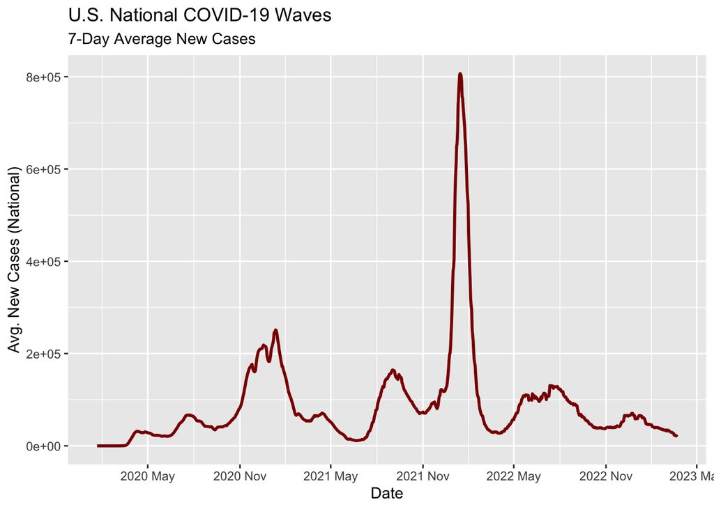

```r
library(ggplot2)
national_cases <- covid  %>%

  mutate(date = as.Date(date)) %>%

  group_by(date) %>%
  summarise(
    National_Cases_Avg = sum(cases_avg, na.rm = TRUE),
    .groups = 'drop'
  )

covid_spikes_plot <- national_cases %>%
  ggplot(aes(x = date, y = National_Cases_Avg)) +

  geom_line(color = "darkred", linewidth = 1) +

  scale_x_date(
    date_breaks = "6 months",
    date_labels = "%Y %b"
  ) +

  labs(
    title = "U.S. National COVID-19 Waves",
    subtitle = "7-Day Average New Cases",
    x = "Date",
    y = "Avg. New Cases (National)"
  )

print(covid_spikes_plot)
```

## b

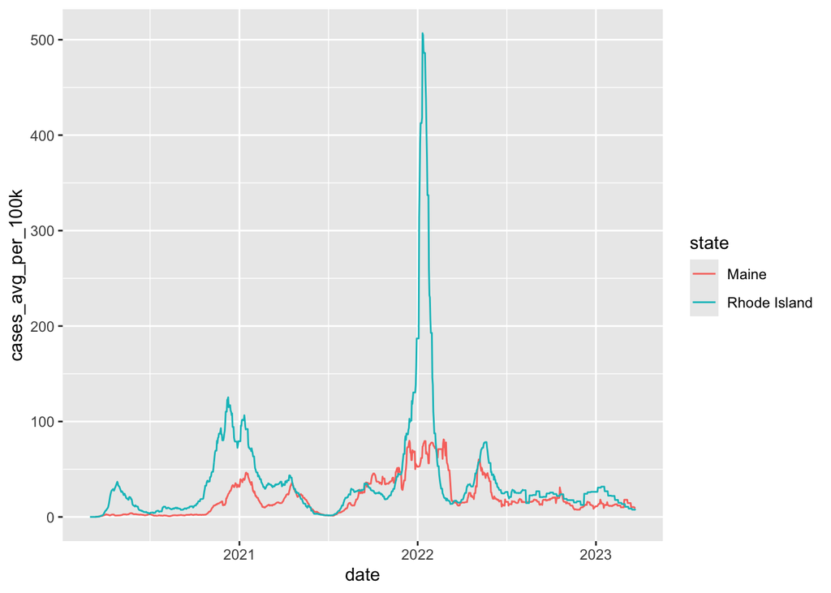

```r
state_ranking <- covid %>%
  mutate(date = as.Date(date)) %>%
  group_by(state) %>%
  summarise(Cumulative_Rate = sum(cases_avg_per_100k, na.rm = TRUE), .groups = 'drop') %>%
  arrange(desc(Cumulative_Rate))

highest_state_name <- head(state_ranking$state, 1)
lowest_state_name <- tail(state_ranking$state, 1)

comparison_data <- covid %>%
  filter(state %in% c(highest_state_name, lowest_state_name)) %>%
  mutate(date = as.Date(date))

trajectory_plot <- comparison_data %>%
  ggplot(aes(x = date,
             y = cases_avg_per_100k,
             color = state)) +

  geom_line()

print(trajectory_plot)
```

## c

The criterion used to define “substantial” is a 7-day average of 150 or more new cases per 100K residents. The top 5 states are North Dakota, South Dakota, Wyoming, Alaska, and Northern Mariana Islands

```r
top_5_states_info <- covid %>%
  mutate(date = as.Date(date)) %>%
  filter(cases_avg_per_100k >= 150) %>%
  group_by(state) %>%
  summarise(first_exp = min(date)) %>%
  arrange(first_exp) %>%
  slice_head(n = 5) %>%
  pull(state)
cat(top_5_states_info)
```

```
North Dakota South Dakota Wyoming Alaska Northern Mariana Islands
```

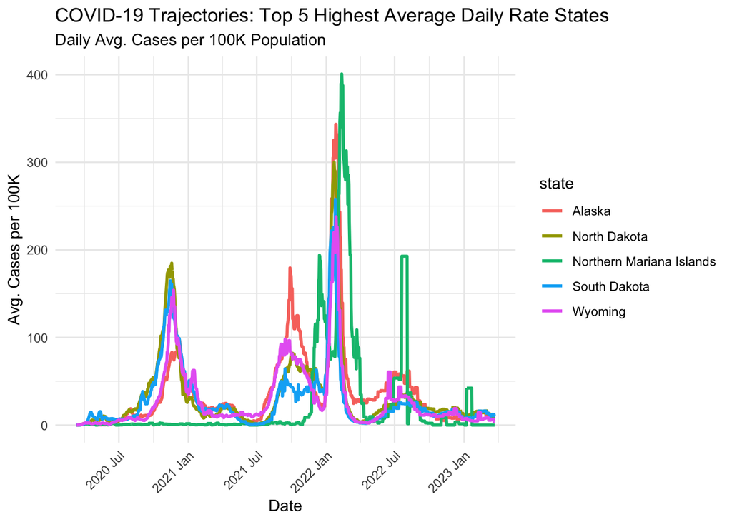

```r
plot_data_top5 <- covid %>%
  filter(state %in% top_5_states_info) %>%
  mutate(date = as.Date(date))

trajectory_plot_top5_avg <- plot_data_top5 %>%
  ggplot(aes(x = date,
             y = cases_avg_per_100k,
             color = state)) +

  geom_line(linewidth = 1) +
  scale_x_date(date_breaks = "6 months", date_labels = "%Y %b") +

  labs(
    title = "COVID-19 Trajectories: Top 5 Highest Average Daily Rate States",
    subtitle = "Daily Avg. Cases per 100K Population",
    x = "Date",
    y = "Avg. Cases per 100K"
  ) +
  theme_minimal() +
  theme(
    axis.text.x = element_text(angle = 45, hjust = 1)
  )

trajectory_plot_top5_avg
```